# devoir-3

BOUKHARI Adem, MAHDI Ryma

# Rapport de Projet d’Apprentissage Automatique

## Aperçu du Projet

Dans ce rapport, nous présentons les détails et les résultats de notre projet d’apprentissage automatique. L’objectif de ce projet était de prédire le succès ou l’échec du traitement chez les patients à partir de mesures réalisées à la ligne de base. Les données utilisées dans cette étude proviennent de la première étude du National Institute of Drug Abuse Clinical Trials Network, qui a évalué l’efficacité clinique du buprénorphine-naloxone (bup-nx) et de la clonidine pour la désintoxication des opioïdes dans les programmes de traitement en milieu hospitalier et en ambulatoire.

## Introduction

La désintoxication des opioïdes est une étape cruciale dans le traitement des personnes dépendantes aux opioïdes. Dans ce projet, notre objectif était de développer des modèles prédictifs capables d’estimer si un patient aurait un succès ou un échec au traitement, en se basant sur les mesures recueillies lors de la ligne de base. Cela pourrait aider les professionnels de la santé à prendre des décisions éclairées sur le type de traitement à proposer à chaque patient.

## Description de l’Ensemble de Données

L’ensemble de données utilisé dans ce projet comprend des informations sur des patients diagnostiqués selon les critères du Diagnostic and Statistical Manual version IV (DSM IV) comme dépendants aux opioïdes et recherchant un traitement à court terme. Les patients ont été assignés de manière aléatoire, avec une proportion de 2:1 en faveur du bup-nx, à une désintoxication de 13 jours utilisant soit le bup-nx soit la clonidine. Au total, 113 patients en milieu hospitalier (77 bup-nx, 36 clonidine) et 231 patients en ambulatoire (157 bup-nx, 74 clonidine) ont participé à l’étude.

## Analyse Exploratoire des Données (AED)

Lors de l’analyse exploratoire des données, nous avons effectué les observations suivantes :

Parmi les patients en milieu hospitalier, 77% des patients assignés à la condition bup-nx ont atteint le critère de succès du traitement, comparé à seulement 22% des patients assignés à la clonidine. Parmi les patients en ambulatoire, 29% des patients assignés à la condition bup-nx ont atteint le critère de succès du traitement, tandis que seulement 5% des patients assignés à la clonidine l’ont atteint. Ces observations initiales soulignent l’importance potentielle du bup-nx pour la désintoxication des opioïdes.

```r
summary(df)
```

```
##  STUDYID ARM          AGE        GENDER     EDUCYRS         BMI
##  0:113   0:110   Min.   :18.86   0:233   12     :131   Min.   : 0.2228
##  1:230   1:233   1st Qu.:29.51   1:110   14     : 51   1st Qu.:21.8934
##                  Median :39.46           11     : 38   Median :24.3636
##                  Mean   :37.96           13     : 34   Mean   :25.0800
##                  3rd Qu.:45.63           16     : 21   3rd Qu.:27.7595
##                  Max.   :65.00           10     : 20   Max.   :46.4493
##                                          (Other): 48   NA's   :4
##       SBP             DBP             PULSE             RESP
##  Min.   : 94.0   Min.   : 50.00   Min.   : 47.00   Min.   : 1.00
##  1st Qu.:110.0   1st Qu.: 70.00   1st Qu.: 68.00   1st Qu.:16.00
##  Median :119.8   Median : 78.00   Median : 74.00   Median :16.00
##  Mean   :121.8   Mean   : 80.58   Mean   : 76.07   Mean   :16.79
##  3rd Qu.:130.0   3rd Qu.: 86.00   3rd Qu.: 84.00   3rd Qu.:18.00
##  Max.   :182.0   Max.   :701.00   Max.   :131.00   Max.   :31.00
##  NA's   :3       NA's   :3        NA's   :4        NA's   :8
##       TEMP          VASC1.SC     METHADONE.SC MORPHINE.SC MARITAL.DIVORCED
##  Min.   : 95.0   Min.   :  0.0   0   :311     0   : 96    0:288
##  1st Qu.: 97.9   1st Qu.: 50.0   1   : 31     1   :246    1: 55
##  Median : 98.4   Median : 73.0   NA's:  1     NA's:  1
##  Mean   :101.0   Mean   : 66.9
##  3rd Qu.: 98.8   3rd Qu.: 92.0
##  Max.   :999.9   Max.   :100.0
##  NA's   :8       NA's   :12
##  MARITAL.LEGALLY MARRIED MARITAL.LIVING WITH PARTNER/COHABITATING
##  0:281                   0:311
##  1: 62                   1: 32
##
##
##
##
##
##  MARITAL.NEVER MARRIED MARITAL.SEPARATED MARITAL.WIDOWED
##  0:183                 0:317             0:335
##  1:160                 1: 26             1:  8
##
##
##
##
##
```

[output cut: 25 more lines]

```
##  0   :323                              0   :335
##  1   : 19                              1   :  7
##  NA's:  1                              NA's:  1
##
##
##
##
##  EMPLOYEMENT.STUDENT EMPLOYEMENT.UNEMPLOYED TARGET
##  0   :331            0   :285               0:108
##  1   : 11            1   : 57               1:235
##  NA's:  1            NA's:  1
##
##
##
##
```

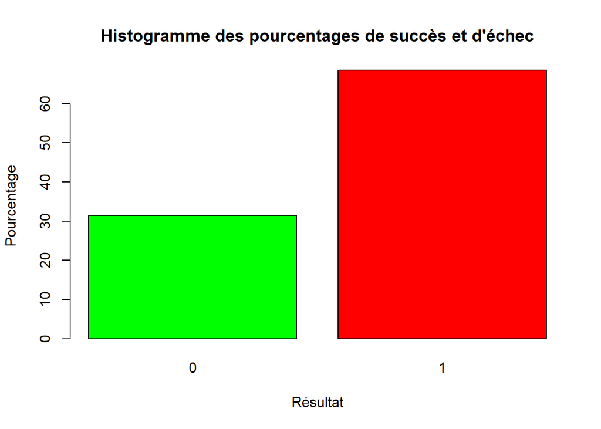

```r
# Calculer les pourcentages de réussite et d'échec
percentages <- prop.table(table(df$TARGET)) * 100
# Créer un histogramme des pourcentages
barplot(percentages, col = c("green", "red"), xlab = "Résultat", ylab = "Pourcentage", main = "Histogramme des pourcentages de succès et d'échec")
```

## Prétraitement des Données

Avant de construire nos modèles d’apprentissage automatique, nous avons effectué des étapes de prétraitement des données pour assurer leur qualité et les préparer pour l’analyse. Les étapes de prétraitement que nous avons effectuées sont les suivantes :

### Gestion des valeurs manquantes :

Nous avons identifié les valeurs manquantes dans l’ensemble de données et avons effectué une imputation des valeurs manquantes avec missforest

```r
set.seed(70)
df <- missForest(df, maxiter = 10, verbose = T)
```

```
##   missForest iteration 1 in progress...done!
##     estimated error(s): 0.599019 0.02951824
##     difference(s): 0.0002981167 0
##     time: 3.26 seconds
##
##   missForest iteration 2 in progress...done!
##     estimated error(s): 0.6003467 0.02868282
##     difference(s): 0.0002544176 0
##     time: 2.72 seconds
##
##   missForest iteration 3 in progress...done!
##     estimated error(s): 0.5952391 0.03007519
##     difference(s): 0.0002709723 0
##     time: 3.1 seconds
```

```r
df <- df$ximp
```

### Encodage des variables catégorielles :

Nous avons identifié les variables catégorielles dans l’ensemble de données et les avons encodées en utilisant la technique du encodage one-hot.

```r
table1$MARITAL<- as.factor(table1$MARITAL)
marital_model <- dummyVars(~ MARITAL, data = table1)
marital_data <- predict(marital_model, newdata = table1)
table1 <- cbind(table1,marital_data)

####EMPLOYEMENT####
table1$EMPLOYEMENT<- as.factor(table1$EMPLOYEMENT)
employement_model <- dummyVars(~ EMPLOYEMENT, data = table1)
employement_data <- predict(employement_model, newdata = table1)
table1 <- cbind(table1,employement_data)
```

### Séparation de l’ensemble de données :

Nous avons divisé l’ensemble de données en deux parties distinctes : un ensemble d’entraînement (80%) et un ensemble de validation (20%).

```r
# Create an index for data partitioning
index <- createDataPartition(df_renomme$TARGET, p = 0.8, list = FALSE)

# Split the data into training and testing sets
train_data <- df_renomme[index, ]
test_data <- df_renomme[-index, ]
test_data_ref <- df_renomme[-index, ]
```

## Méthodologie

Dans ce projet, nous avons utilisé trois modèles d’apprentissage automatique pour prédire le statut de succès ou d’échec du traitement d’un patient : XGBoost, SVM et Random Forest. Nous avons évalué les performances des modèles en utilisant l’accuracy comme métrique d’évaluation.

## Résultats

Les résultats obtenus à partir des trois modèles d’apprentissage automatique ont montré des performances prometteuses dans la prédiction du statut de succès ou d’échec du traitement chez les patients. Voici les résultats de l’évaluation basée sur l’exactitude :

```r
ctrl <- trainControl(method = "cv", number = 10)
########### RANDOM FOREST#################

# Train a random forest model using the train() function
set.seed(777)
RFmodel <- train(TARGET ~ STUDYID+AGE+ARM+GENDER+BMI+METHADONE.SC+SBP+MORPHINE.SC+DBP+PULSE+RESP+VASC1.SC +PULSE +EDUCYRS
, data = train_data, method = "rf", trControl = ctrl)
RFmodel
```

```
## Random Forest
##
## 275 samples
##  13 predictor
##   2 classes: '0', '1'
##
## No pre-processing
## Resampling: Cross-Validated (10 fold)
## Summary of sample sizes: 247, 247, 247, 247, 247, 247, ...
## Resampling results across tuning parameters:
##
##   mtry  Accuracy   Kappa
##    2    0.6873626  0.06630914
##   13    0.6907916  0.24324253
##   25    0.6836386  0.23471642
##
## Accuracy was used to select the optimal model using the largest value.
## The final value used for the model was mtry = 13.
```

```r
# Predict values using the trained random forest model
RFpredictions <- predict(RFmodel, newdata = test_data)

# Create a confusion matrix
confusion <- confusionMatrix(RFpredictions, reference = test_data_ref$TARGET)
confusion
```

```
## Confusion Matrix and Statistics
##
##           Reference
## Prediction  0  1
##          0 13  6
##          1  8 41
##
##                Accuracy : 0.7941
##                  95% CI : (0.6788, 0.8826)
##     No Information Rate : 0.6912
##     P-Value [Acc > NIR] : 0.04038
##
##                   Kappa : 0.5047
##
##  Mcnemar's Test P-Value : 0.78927
##
##             Sensitivity : 0.6190
##             Specificity : 0.8723
##          Pos Pred Value : 0.6842
##          Neg Pred Value : 0.8367
##              Prevalence : 0.3088
##          Detection Rate : 0.1912
##    Detection Prevalence : 0.2794
##       Balanced Accuracy : 0.7457
##
##        'Positive' Class : 0
##
```

```r
############# SVM ###############################
set.seed(777)
SVmodel <- train(TARGET ~ STUDYID+AGE+ARM+GENDER+METHADONE.SC+BMI+SBP+MORPHINE.SC+DBP+PULSE+EDUCYRS+RESP+TEMP+VASC1.SC
, data = train_data, method = "svmLinear", trControl = ctrl)
SVmodel
```

```
## Support Vector Machines with Linear Kernel
##
## 275 samples
##  14 predictor
##   2 classes: '0', '1'
##
## No pre-processing
## Resampling: Cross-Validated (10 fold)
## Summary of sample sizes: 247, 247, 247, 247, 247, 247, ...
## Resampling results:
##
##   Accuracy   Kappa
##   0.7487281  0.3713827
##
## Tuning parameter 'C' was held constant at a value of 1
```

```r
# Predict values using the trained random forest model
SVpredictions <- predict(SVmodel, newdata = test_data)

# Create a confusion matrix
confusion2 <- confusionMatrix(SVpredictions, reference = test_data_ref$TARGET)
confusion2
```

```
## Confusion Matrix and Statistics
##
##           Reference
## Prediction  0  1
##          0 12  3
##          1  9 44
##
##                Accuracy : 0.8235
##                  95% CI : (0.712, 0.9053)
##     No Information Rate : 0.6912
##     P-Value [Acc > NIR] : 0.01016
##
##                   Kappa : 0.5512
##
##  Mcnemar's Test P-Value : 0.14891
##
##             Sensitivity : 0.5714
##             Specificity : 0.9362
##          Pos Pred Value : 0.8000
##          Neg Pred Value : 0.8302
##              Prevalence : 0.3088
##          Detection Rate : 0.1765
##    Detection Prevalence : 0.2206
##       Balanced Accuracy : 0.7538
##
##        'Positive' Class : 0
##
```

```r
############## XGBOOST###########################

set.seed(777)

grid <- expand.grid(nrounds = c(50, 100, 150),
                    max_depth = c(3, 6, 9),
                    eta = c(0.1, 0.5, 0.8))

XGBTREE <- train(TARGET ~ STUDYID+AGE+ARM+GENDER+METHADONE.SC+BMI+SBP+MORPHINE.SC+DBP+PULSE+EDUCYRS+RESP+TEMP+VASC1.SC
                 , data = train_data, method = "xgbTree", trControl = ctrl, verbosity = 0)
XGBTREE
```

```
## eXtreme Gradient Boosting
##
## 275 samples
##  14 predictor
##   2 classes: '0', '1'
##
## No pre-processing
## Resampling: Cross-Validated (10 fold)
## Summary of sample sizes: 247, 247, 247, 247, 247, 247, ...
## Resampling results across tuning parameters:
##
##   eta  max_depth  colsample_bytree  subsample  nrounds  Accuracy   Kappa
##   0.3  1          0.6               0.50        50      0.6611315  0.13720265
##   0.3  1          0.6               0.50       100      0.6398555  0.13294104
##   0.3  1          0.6               0.50       150      0.6503053  0.15895911
##   0.3  1          0.6               0.75        50      0.6873423  0.21252233
##   0.3  1          0.6               0.75       100      0.6577025  0.15396844
##   0.3  1          0.6               0.75       150      0.6685694  0.17641306
##   0.3  1          0.6               1.00        50      0.7123423  0.27116966
##   0.3  1          0.6               1.00       100      0.6833639  0.19364578
##   0.3  1          0.6               1.00       150      0.6759565  0.18458474
##   0.3  1          0.8               0.50        50      0.6946276  0.24599227
##   0.3  1          0.8               0.50       100      0.6651099  0.18403121
##   0.3  1          0.8               0.50       150      0.6397334  0.13945786
##   0.3  1          0.8               0.75        50      0.6939560  0.23075731
##   0.3  1          0.8               0.75       100      0.6575702  0.13576160
##   0.3  1          0.8               0.75       150      0.6578449  0.14743779
##   0.3  1          0.8               1.00        50      0.7050672  0.25391486
##   0.3  1          0.8               1.00       100      0.6798026  0.20305998
##   0.3  1          0.8               1.00       150      0.6686813  0.16957741
##   0.3  2          0.6               0.50        50      0.6577025  0.16801022
##   0.3  2          0.6               0.50       100      0.6610094  0.19210533
##   0.3  2          0.6               0.50       150      0.6501526  0.18179162
##   0.3  2          0.6               0.75        50      0.6800773  0.21620977
##   0.3  2          0.6               0.75       100      0.6540090  0.16916573
##   0.3  2          0.6               0.75       150      0.6430301  0.12673695
##   0.3  2          0.6               1.00        50      0.6902422  0.21969412
##   0.3  2          0.6               1.00       100      0.6791209  0.21075828
##   0.3  2          0.6               1.00       150      0.6717135  0.18062941
##   0.3  2          0.8               0.50        50      0.6609992  0.15903135
```

[output cut: 73 more lines]

```
##   0.4  3          0.8               0.50       150      0.6504375  0.16047541
##   0.4  3          0.8               0.75        50      0.6498779  0.13432726
##   0.4  3          0.8               0.75       100      0.6501526  0.13442202
##   0.4  3          0.8               0.75       150      0.6424807  0.13929416
##   0.4  3          0.8               1.00        50      0.6681420  0.19858724
##   0.4  3          0.8               1.00       100      0.6648555  0.19386447
##   0.4  3          0.8               1.00       150      0.6648555  0.19257168
##
## Tuning parameter 'gamma' was held constant at a value of 0
## Tuning
##  parameter 'min_child_weight' was held constant at a value of 1
## Accuracy was used to select the optimal model using the largest value.
## The final values used for the model were nrounds = 50, max_depth = 1, eta
##  = 0.3, gamma = 0, colsample_bytree = 0.6, min_child_weight = 1 and subsample
##  = 1.
```

```r
# Predict values using the trained random forest model
XGBTREEpredictions <- predict(XGBTREE, newdata = test_data)

# Create a confusion matrix
confusion2 <- confusionMatrix(XGBTREEpredictions, reference = test_data_ref$TARGET)
confusion2
```

```
## Confusion Matrix and Statistics
##
##           Reference
## Prediction  0  1
##          0 10  3
##          1 11 44
##
##                Accuracy : 0.7941
##                  95% CI : (0.6788, 0.8826)
##     No Information Rate : 0.6912
##     P-Value [Acc > NIR] : 0.04038
##
##                   Kappa : 0.4609
##
##  Mcnemar's Test P-Value : 0.06137
##
##             Sensitivity : 0.4762
##             Specificity : 0.9362
##          Pos Pred Value : 0.7692
##          Neg Pred Value : 0.8000
##              Prevalence : 0.3088
##          Detection Rate : 0.1471
##    Detection Prevalence : 0.1912
##       Balanced Accuracy : 0.7062
##
##        'Positive' Class : 0
##
```